# cross sector shocks

June, 2024

## Shock probability across models

To get the yearly shock probability for each combination of sector, climate model, climate experiment, and output_variable, we:

- applied a smoother (loess R function) per ecological model
- extract the z-scored residuals
- counted the number of shocks (beyond 2SD of the mean) across the time-series, and whether the shocks are from increases or decreases in the resource level
- calculated the mean number of shocks across ecological models, as a way to aggregate the model ensembles

Below is the example of maize globally across climates:

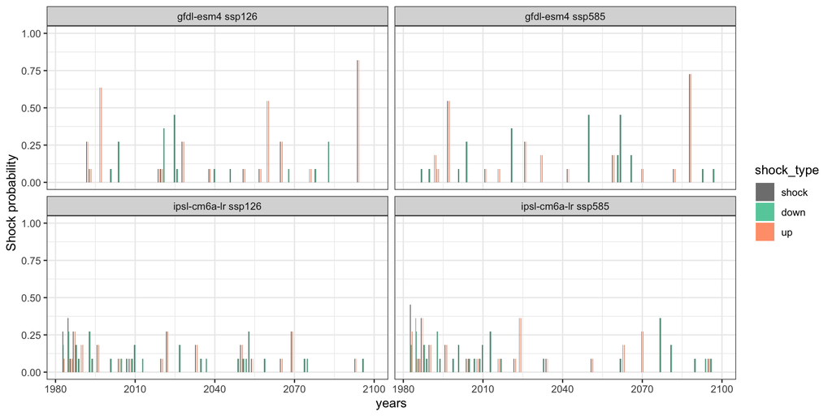

## Shock probability for multiple resources

Shock probabilities for GFDL-ESM4 and SSP585 across sectors and modelled resources:

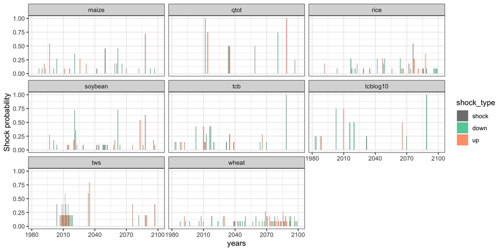

## Cross-sector shock probability

To get the cross-sector shock occurrence probability, we calculate the shock probability from multiple sector together. For this, we selected maize, soybean, rice, wheat, tcblog10, and qtot, and we compute the cross-sector shock probability as follows:

- probability that there is at least one shock per year: P(X>=1) = 1-P(X=0)
- probability that there are at least two shocks per year: P(X>=2) = P(X>=1)-P(X=1)
- probability that there are at least three shocks per year: P(X>=3) = P(X>=2)-P(X=3)

The plot below shows the cross-sector probability across climates globally:

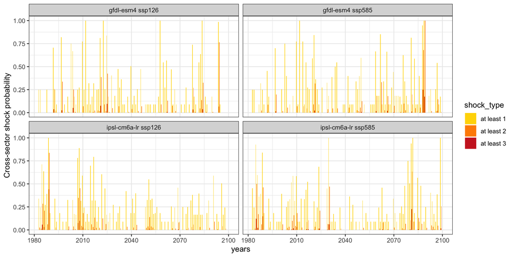

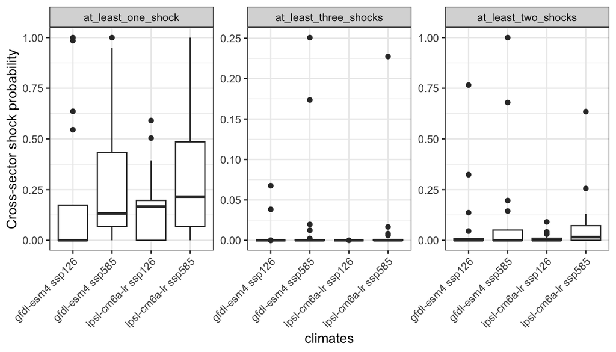

## Cross-sector shock probability across years

To get the cross-sector occurrence probability across years, we calculate the cross-sector probability over the last 10 years that there is:

- at least one shock over the period of time
- at least two shocks in the same year once over the period of time
- at least three shocks in the same year once over the period of time

The graphs show the non-logged and logged probability distribution:

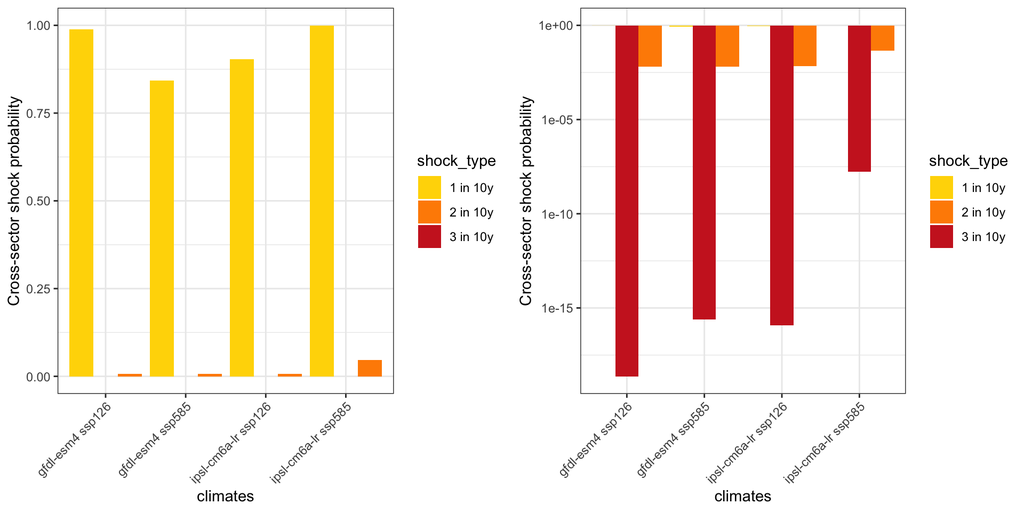

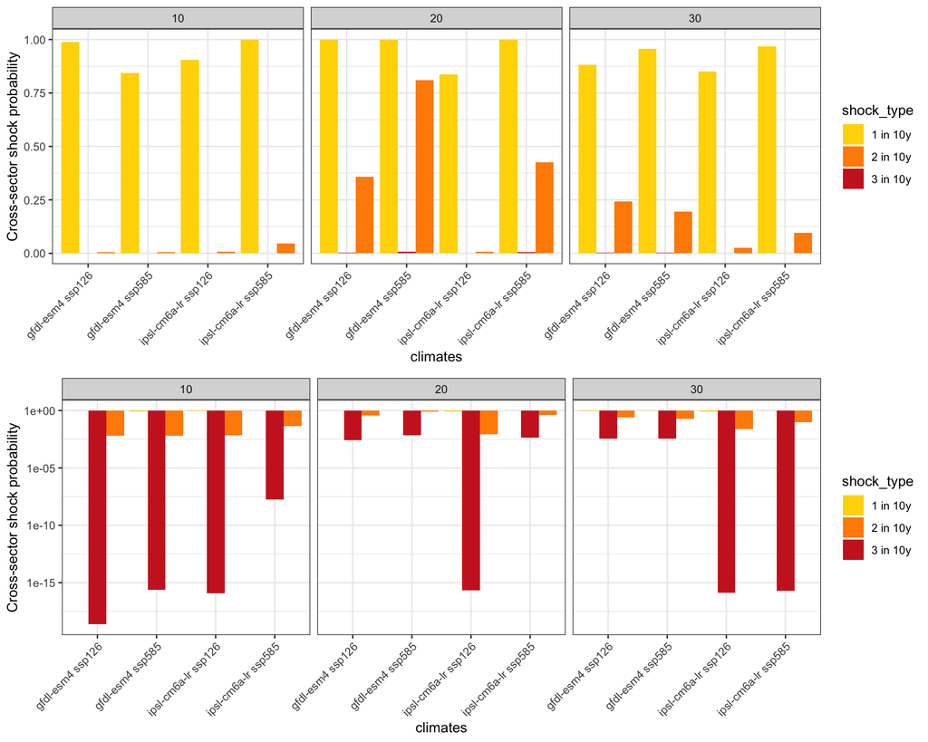